# Personal Information

Name: **Dies de haan**

StudentID: **15879062**

Email: **dies.de.haan@student.uva.nl**

Submitted on: **23.03.2026**

# Data Context

# Data Description

**Present here the results of your exploratory data analysis. Note that there is no need to have a "story line" - it is more important that you show your understanding of the data and the methods that you will be using in your experiments (i.e. your methodology).**

**As an example, you could show data, label, or group balances, skewness, and basic characterizations of the data. Information about data frequency and distributions as well as results from reduction mechanisms such as PCA could be useful. Furthermore, indicate outliers and how/why you are taking them out of your samples, if you do so.**

**The idea is, that you conduct this analysis to a) understand the data better but b) also to verify the shapes of the distributions and whether they meet the assumptions of the methods that you will attempt to use. Finally, make good use of images, diagrams, and tables to showcase what information you have extracted from your data.**

As you can see, you are in a jupyter notebook environment here. This means that you should focus little on writing text and more on actually exploring your data. If you need to, you can use the amsmath environment in-line: $e=mc^2$ or also in separate equations such as here:

\begin{equation} e=mc^2 \mathrm{\space where \space} e,m,c\in \mathbb{R} \end{equation}

Furthermore, you can insert images such as your data aggregation diagrams like this:

[figure not shown]

## Data Sources

This study uses multiple datasets:

### DGW dataset (evaluation) not in EDA

- ~2000 indoor housing images
- Real-world variability (lighting, angle, clutter)

### Key challenge

Datasets differ in:

- Label definitions
- Annotation style
- Instance density
- Presence of "no damage"

```python
import os
import json
import numpy as np
import pandas as pd
import matplotlib.pyplot as plt
import seaborn as sns
from PIL import Image
from collections import Counter
from roboflow import Roboflow
```

# getting api key

```python
def load_api_key(path="apikeyroboflow.txt"):
    with open(path, "r") as f:
        return f.read().strip()

API_KEY = load_api_key()
```

# Getting datasets

```python
downloaded_paths = {
    "asbestos": r"data\asbestos",
    "crack": r"data\crack",
    "house": r"data\house",
    "paint": r"data\paint",
    "mold": r"data\mold",
}
```

```python
from pathlib import Path
import pandas as pd

def count_files(folder, exts):
    folder = Path(folder)
    if not folder.exists():
        return 0
    return sum(1 for f in folder.rglob("*") if f.is_file() and f.suffix.lower() in exts)

def count_dataset(base_path):
    base = Path(base_path)

    return {
        "train_images": count_files(base / "train" / "images", {".jpg", ".jpeg", ".png"}),
        "valid_images": count_files(base / "valid" / "images", {".jpg", ".jpeg", ".png"}),
        "test_images": count_files(base / "test" / "images", {".jpg", ".jpeg", ".png"}),

        "train_labels": count_files(base / "train" / "labels", {".txt"}),
        "valid_labels": count_files(base / "valid" / "labels", {".txt"}),
        "test_labels": count_files(base / "test" / "labels", {".txt"}),
    }

summary = []

for name, path in downloaded_paths.items():
    stats = count_dataset(path)
    stats["dataset"] = name
    summary.append(stats)

df_summary = pd.DataFrame(summary)
df_summary
```

|  | train_images | valid_images | test_images | train_labels | valid_labels | test_labels | dataset |
| --- | --- | --- | --- | --- | --- | --- | --- |
| 0 | 932 | 266 | 133 | 932 | 266 | 133 | asbestos |
| 1 | 3717 | 200 | 112 | 3717 | 200 | 112 | crack |
| 2 | 3008 | 0 | 562 | 3008 | 0 | 562 | house |
| 3 | 0 | 0 | 67 | 0 | 0 | 67 | paint |
| 4 | 1416 | 0 | 0 | 1416 | 0 | 0 | mold |

### Dataset Characteristics

The datasets show significant differences in size and structure.

- The crack and house datasets are substantially larger than the others
- The paint dataset is very small and only contains test samples
- The mold dataset only contains training data
- The house dataset lacks a validation split

This indicates strong heterogeneity across datasets.

### Implications

These differences have several implications:

- Larger datasets (crack, house) will dominate model learning
- Missing splits require careful handling during training and evaluation
- Small datasets (paint) may not contribute significantly to training
- The model must generalize across datasets with inconsistent structures

This variability reflects realistic conditions and is relevant for evaluating robustness.

### Analysis 1:

# Total sizes + ratios

```python
df = df_summary.copy()

df["total_images"] = (
    df["train_images"] +
    df["valid_images"] +
    df["test_images"]
)

df["train_ratio"] = df["train_images"] / df["total_images"]
df["valid_ratio"] = df["valid_images"] / df["total_images"]
df["test_ratio"] = df["test_images"] / df["total_images"]

df
```

|  | train_images | valid_images | test_images | train_labels | valid_labels | test_labels | dataset | total_images | train_ratio | valid_ratio | test_ratio |
| --- | --- | --- | --- | --- | --- | --- | --- | --- | --- | --- | --- |
| 0 | 932 | 266 | 133 | 932 | 266 | 133 | asbestos | 1331 | 0.700225 | 0.19985 | 0.099925 |
| 1 | 3717 | 200 | 112 | 3717 | 200 | 112 | crack | 4029 | 0.922561 | 0.04964 | 0.027798 |
| 2 | 3008 | 0 | 562 | 3008 | 0 | 562 | house | 3570 | 0.842577 | 0.00000 | 0.157423 |
| 3 | 0 | 0 | 67 | 0 | 0 | 67 | paint | 67 | 0.000000 | 0.00000 | 1.000000 |
| 4 | 1416 | 0 | 0 | 1416 | 0 | 0 | mold | 1416 | 1.000000 | 0.00000 | 0.000000 |

# Dataset size

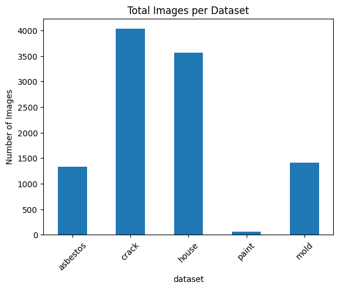

```python
plt.figure()
df.set_index("dataset")["total_images"].plot(kind="bar")
plt.title("Total Images per Dataset")
plt.ylabel("Number of Images")
plt.xticks(rotation=45)
plt.show()
```

# split distribution

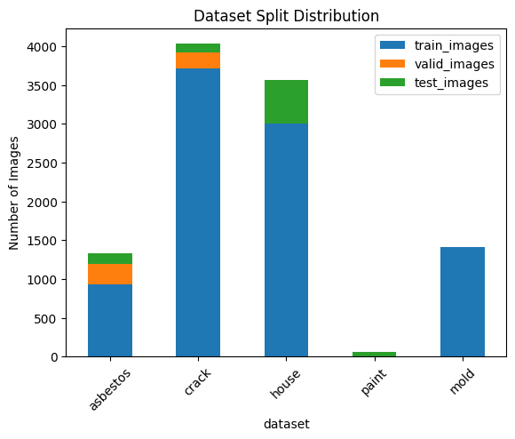

```python
df_split = df.set_index("dataset")[["train_images", "valid_images", "test_images"]]

plt.figure()
df_split.plot(kind="bar", stacked=True)
plt.title("Dataset Split Distribution")
plt.ylabel("Number of Images")
plt.xticks(rotation=45)
plt.show()
```

# Split ratio comparison

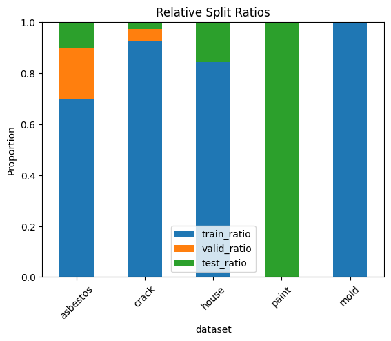

```python
df_ratio = df.set_index("dataset")[["train_ratio", "valid_ratio", "test_ratio"]]

plt.figure()
df_ratio.plot(kind="bar", stacked=True)
plt.title("Relative Split Ratios")
plt.ylabel("Proportion")
plt.xticks(rotation=45)
plt.show()
```

# Annotation density

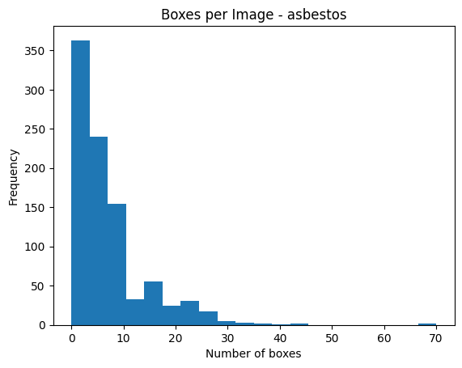

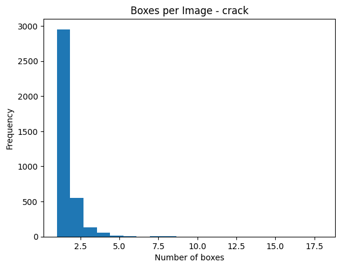

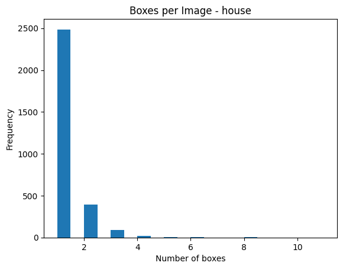

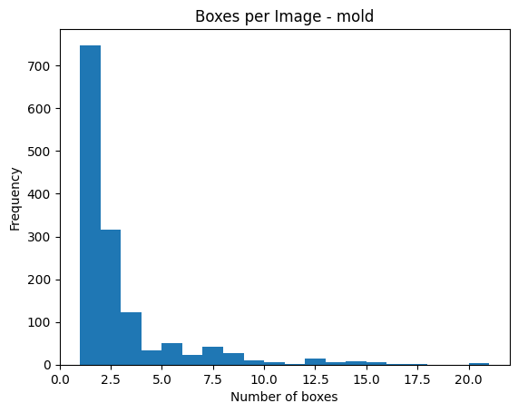

```python
def boxes_per_image(path):
    counts = []
    path = Path(path)

    for file in path.rglob("*.txt"):
        with open(file) as f:
            counts.append(len(f.readlines()))
    return counts

for name, path in downloaded_paths.items():
    label_path = Path(path) / "train" / "labels"

    if not label_path.exists():
        continue

    counts = boxes_per_image(label_path)

    if len(counts) == 0:
        continue

    plt.figure()
    plt.hist(counts, bins=20)
    plt.title(f"Boxes per Image - {name}")
    plt.xlabel("Number of boxes")
    plt.ylabel("Frequency")
    plt.show()
```

# Average boxes per image

```python
avg_boxes = {}

for name, path in downloaded_paths.items():
    label_path = Path(path) / "train" / "labels"

    if not label_path.exists():
        avg_boxes[name] = 0
        continue

    counts = boxes_per_image(label_path)

    avg_boxes[name] = sum(counts) / len(counts) if counts else 0

df_boxes = pd.DataFrame.from_dict(avg_boxes, orient="index", columns=["avg_boxes_per_image"])
df_boxes
```

|  | avg_boxes_per_image |
| --- | --- |
| asbestos | 7.041845 |
| crack | 1.316384 |
| house | 1.245013 |
| paint | 0.000000 |
| mold | 2.439972 |

# classes count

```python
import yaml

class_counts = {}

for name, path in downloaded_paths.items():
    yaml_path = Path(path) / "data.yaml"

    if yaml_path.exists():
        with open(yaml_path) as f:
            data = yaml.safe_load(f)
            class_counts[name] = len(data.get("names", []))
    else:
        class_counts[name] = 0

df_classes = pd.DataFrame.from_dict(class_counts, orient="index", columns=["num_classes"])
df_classes
```

|  | num_classes |
| --- | --- |
| asbestos | 4 |
| crack | 1 |
| house | 4 |
| paint | 1 |
| mold | 5 |

# combining key metrics

```python
df_analysis = df.set_index("dataset").join(df_boxes).join(df_classes)
df_analysis
```

| dataset | train_images | valid_images | test_images | train_labels | valid_labels | test_labels | total_images | train_ratio | valid_ratio | test_ratio | avg_boxes_per_image | num_classes |
| --- | --- | --- | --- | --- | --- | --- | --- | --- | --- | --- | --- | --- |
| asbestos | 932 | 266 | 133 | 932 | 266 | 133 | 1331 | 0.700225 | 0.19985 | 0.099925 | 7.041845 | 4 |
| crack | 3717 | 200 | 112 | 3717 | 200 | 112 | 4029 | 0.922561 | 0.04964 | 0.027798 | 1.316384 | 1 |
| house | 3008 | 0 | 562 | 3008 | 0 | 562 | 3570 | 0.842577 | 0.00000 | 0.157423 | 1.245013 | 4 |
| paint | 0 | 0 | 67 | 0 | 0 | 67 | 67 | 0.000000 | 0.00000 | 1.000000 | 0.000000 | 1 |
| mold | 1416 | 0 | 0 | 1416 | 0 | 0 | 1416 | 1.000000 | 0.00000 | 0.000000 | 2.439972 | 5 |

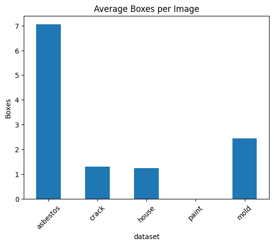

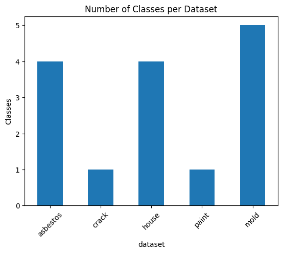

```python
plt.figure()
df_analysis["avg_boxes_per_image"].plot(kind="bar")
plt.title("Average Boxes per Image")
plt.ylabel("Boxes")
plt.xticks(rotation=45)
plt.show()

plt.figure()
df_analysis["num_classes"].plot(kind="bar")
plt.title("Number of Classes per Dataset")
plt.ylabel("Classes")
plt.xticks(rotation=45)
plt.show()
```

### Relevance to the Research Objective

The identified dataset characteristics directly impact the comparison between YOLOv8 and LLaVA.

YOLOv8 relies on structured bounding box annotations and is therefore sensitive to:

- dataset imbalance
- annotation consistency
- availability of training and validation splits

In contrast, LLaVA operates as a vision-language model and may be less dependent on strict annotation structures, potentially allowing it to generalize better across heterogeneous datasets.

This difference makes the dataset variability particularly relevant for evaluating the robustness of both approaches.

### Implications for Methodology

Based on the EDA, the following steps are required:

- Standardization of labels across datasets
- Handling of missing dataset splits
- Careful interpretation of results due to dataset imbalance

These steps ensure a fair and meaningful comparison between YOLOv8 and LLaVA.